# MEFISTO application to evodevo data

Britta Velten & Junyan Lu

Heidelberg University, Germany

britta.velten@cos.uni-heidelberg.de

February 2024

```r
library(MOFA2)
library(magrittr)
library(tidyverse)
library(cowplot)
library(reshape2)
```

# 1 Load data

The data for this vignette can be downloaded from [here](https://figshare.com/s/242916198fde3353f3e6) and placed in a `data/` directory. You should then have two files:

- `data/evodevo.RData` containing the expression data used as input
- `data/evodevo_model.hdf5` containing the pre-trained MEFISTO model

We first load the data frame that contains the gene expression data for all organs (views) and species (groups) as well as the (unmatched) time annotation for each sample.

```r
load("data/evodevo.RData")
head(evodevo)
```

```
## # A tibble: 6 × 6
##   group view  sample      feature               value  time
##   <chr> <chr> <chr>       <chr>                 <dbl> <dbl>
## 1 Human Brain 10wpc_Human ENSG00000000457_Brain  8.57     7
## 2 Human Brain 10wpc_Human ENSG00000001084_Brain  8.88     7
## 3 Human Brain 10wpc_Human ENSG00000001167_Brain 11.3      7
## 4 Human Brain 10wpc_Human ENSG00000001461_Brain  7.37     7
## 5 Human Brain 10wpc_Human ENSG00000001561_Brain  7.31     7
## 6 Human Brain 10wpc_Human ENSG00000001617_Brain  9.96     7
```

**Question 1: Can you visualise the distribution of the data points in each view? Why is it important to visualise the distribution before performing MOFA?**

# 2 Prepare and train MOFA

*Create the MOFA object*

First, we need to create a MOFA object from this data. This step is analogous to use of MOFA without the time information and can be done using `create_mofa`, which results in an untrained MOFA object.

```r
# create the MOFA object and add times as covariate
MOFAobject_untrained <- create_mofa(data = evodevo)
MOFAobject_untrained
```

```
## Untrained MOFA model with the following characteristics:
##  Number of views: 5
##  Views names: Brain Cerebellum Heart Liver Testis
##  Number of features (per view): 7696 7696 7696 7696 7696
##  Number of groups: 5
##  Groups names: Human Mouse Opossum Rabbit Rat
##  Number of samples (per group): 23 14 15 15 16
##
```

**Question 2: What type of data object (matrix, data frame, list, array..) are we using as the input for creating MOFA object in this tutorial? What did we use in the previous tutorial with CLL data? Why is there a difference?**

Next, we want to add the time information for each sample, which we can do using `set_covariates`. As the time is already contained in the data.frame that we passed to the MOFAobject in `create_mofa`, we can just specify to use this column as a covariate. Alternatively, we could also supply a new matrix or data frame providing the sample names and covariates. See `?set_covariates`.

```r
head(samples_metadata(MOFAobject_untrained))
```

```
##                  sample group time
## 10wpc_Human 10wpc_Human Human    7
## 11wpc_Human 11wpc_Human Human    8
## 12wpc_Human 12wpc_Human Human    9
## 13wpc_Human 13wpc_Human Human   10
## 16wpc_Human 16wpc_Human Human   11
## 18wpc_Human 18wpc_Human Human   12
```

```r
MOFAobject_untrained <- set_covariates(MOFAobject_untrained, covariates = "time")
MOFAobject_untrained
```

```
## Untrained MEFISTO model with the following characteristics:
##  Number of views: 5
##  Views names: Brain Cerebellum Heart Liver Testis
##  Number of features (per view): 7696 7696 7696 7696 7696
##  Number of groups: 5
##  Groups names: Human Mouse Opossum Rabbit Rat
##  Number of samples (per group): 23 14 15 15 16
##  Number of covariates per sample: 1
##
```

**Show data and time covariate** Before moving towards the training, let’s first take a look at the data in the untrained object. The plot shows for species (groups) which organ (view) are available for which samples. The right plots show the time values for each sample.

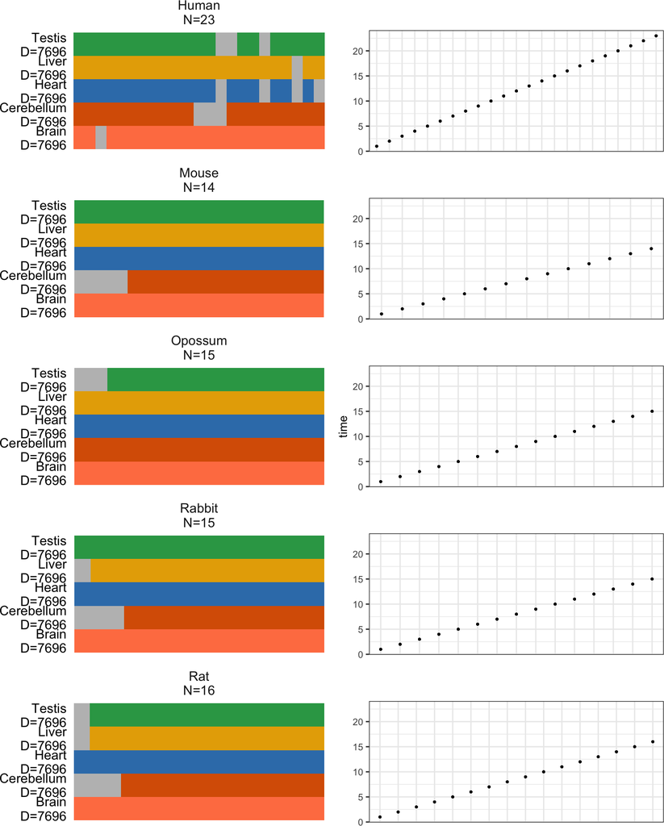

```r
gg_input <- plot_data_overview(MOFAobject_untrained,
                               show_covariate = TRUE,
                               show_dimensions = TRUE)
gg_input
```

**Prepare the MOFA object** Next, we prepare the model for training. For this we specify the different options. Similar to the standard MOFA workflow we define data, model and training options. Take a look at `get_default_data_options`, `get_default_model_options` and `get_default_training_options` to see what options can be specified. Here, we specify that we want to use 5 factors and set a seed for reproducibility.

In addition, for MEFISTO we can specify MEFISTO-specific options, see `get_default_mefisto_options`. Here, we specify that we want to align the times across species using Mouse as a reference group. Furthermore, we can optionally specify time points (when using warping these correspond to times in the reference group), for which to interpolate the factors in all groups.

```r
data_opts <- get_default_data_options(MOFAobject_untrained)

model_opts <- get_default_model_options(MOFAobject_untrained)
model_opts$num_factors <- 5

train_opts <- get_default_training_options(MOFAobject_untrained)
train_opts$seed <- 2020
train_opts$convergence_mode <- "medium" # use "fast" for faster training

mefisto_opts <- get_default_mefisto_options(MOFAobject_untrained)
mefisto_opts$warping <- TRUE
mefisto_opts$warping_ref <- "Mouse"
mefisto_opts$new_values <- 1:14
```

We then pass all these options to the object.

```r
MOFAobject_untrained <- prepare_mofa(
  object = MOFAobject_untrained,
  data_options = data_opts,
  model_options = model_opts,
  training_options = train_opts,
  mefisto_options = mefisto_opts
)
```

**Train the MOFA model**

As the model training might take ~15 min, for all further analysis we will use a pre-trained model. In addition to the factor values at the observed data points we can optionally load the interpolated data.  
If you want to perform the training step, you can simply un-comment the code in the next chunk and excute the `run_mofa` function.

```r
outfile <- "data/evodevo_model.hdf5"
MOFAobject <- load_model(outfile, load_interpol_Z = TRUE)
```

Below code is for model training.

```r
# MOFAobject <- run_mofa(MOFAobject_untrained, outfile = outfile, use_basilisk = TRUE)
```

We can add a species column to the metadata for further down-stream analysis.

```r
samples_metadata(MOFAobject) %<>% mutate(species = group)
```

# 3 Factor overview and visualization

**Question 3: Based on what you have learnt from the previous CLL tutorial, what is normally the first analysis step after you train a MOFA model? How to perform it?**

## 3.1 Factors versus developmental time (before/after alignement)

To look at the inferred factors, we can plot them against the developmental stages. Before alignment, the timing of common developmental process does not match, after alignment, we see a clearer match.

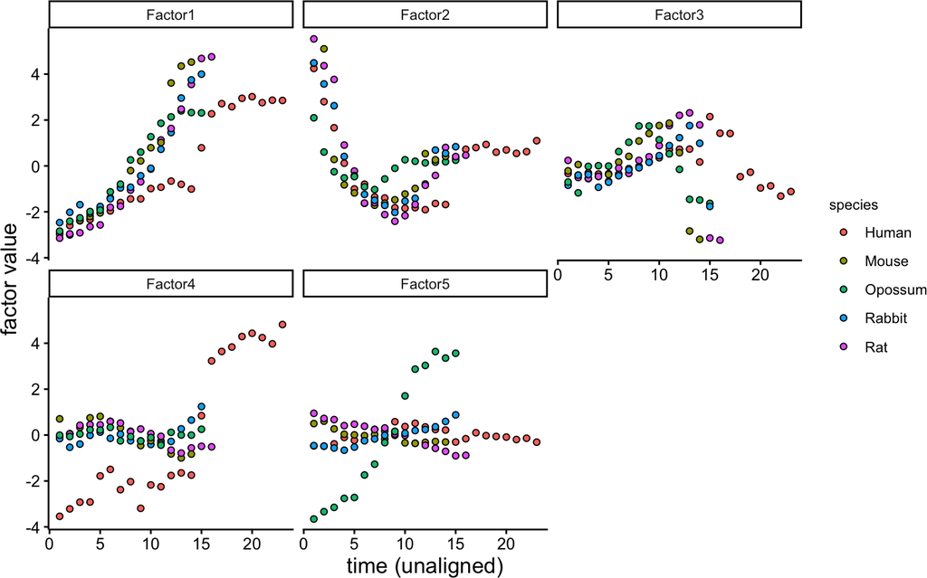

```r
# Factors versus developmental time (before alignment)
plot_factors_vs_cov(MOFAobject, color_by = "species",
                    covariate = "time",  warped = FALSE)
```

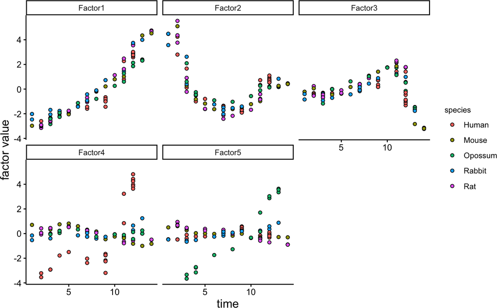

```r
# Factors versus developmental time (after alignment)
plot_factors_vs_cov(MOFAobject, color_by = "species",
                    covariate = "time", warped = TRUE)
```

## 3.2 Interpolation

Using the underlying Gaussian process for each factor we can interpolate to unseen time points for species that are missing data in these time points or intermediate time points. If you want to show uncertainties, set only_mean to FALSE. Note that these are only available if the new values for interpolation have been specified before training.

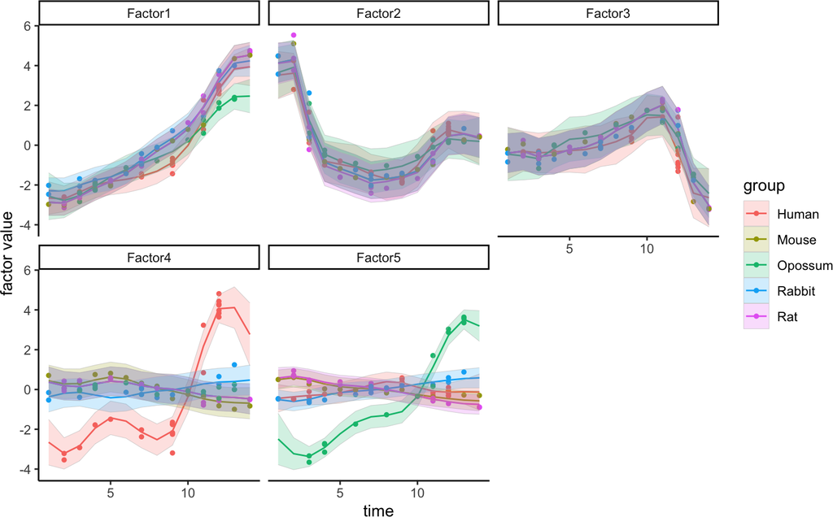

```r
plot_interpolation_vs_covariate(MOFAobject, only_mean = FALSE)
```

```r
# if the interpolation was not specified in mefisto_options before training
# or you want to interpolate to new values you can use interpolate_factors
# this however does not provide uncertainties
MOFAobject_new <- interpolate_factors(MOFAobject,
                                  new_values = seq(1, 14, 0.1))
```

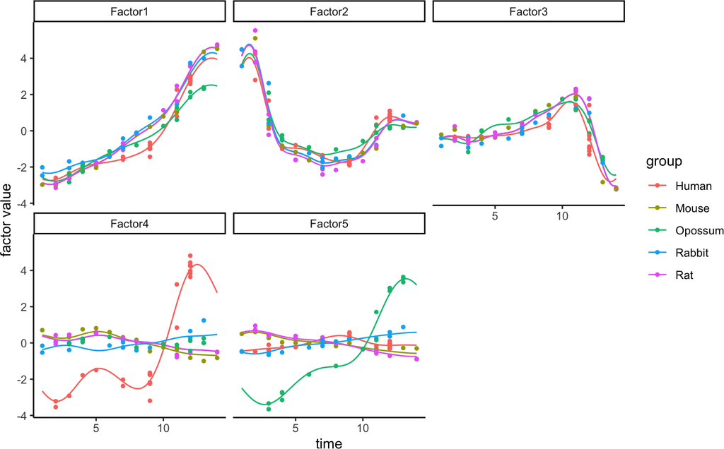

```r
plot_interpolation_vs_covariate(MOFAobject_new)
```

## 3.3 Factor scatter plot

A scatter plot of the first two factors shows the embedding of timepoint-species combination in the latent space. Again we see, that the aligned times show a gradual development along the developmental trajectory captured by the conserved developmental programs on Factors 1 and 2.

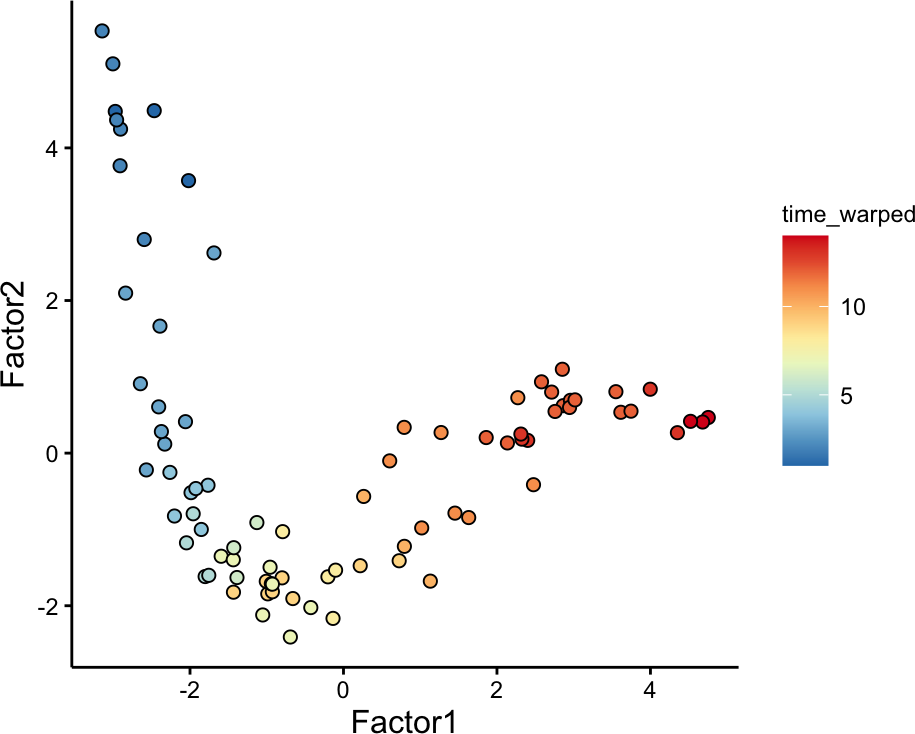

```r
plot_factors(MOFAobject, 1:2, color_by = "time_warped")
```

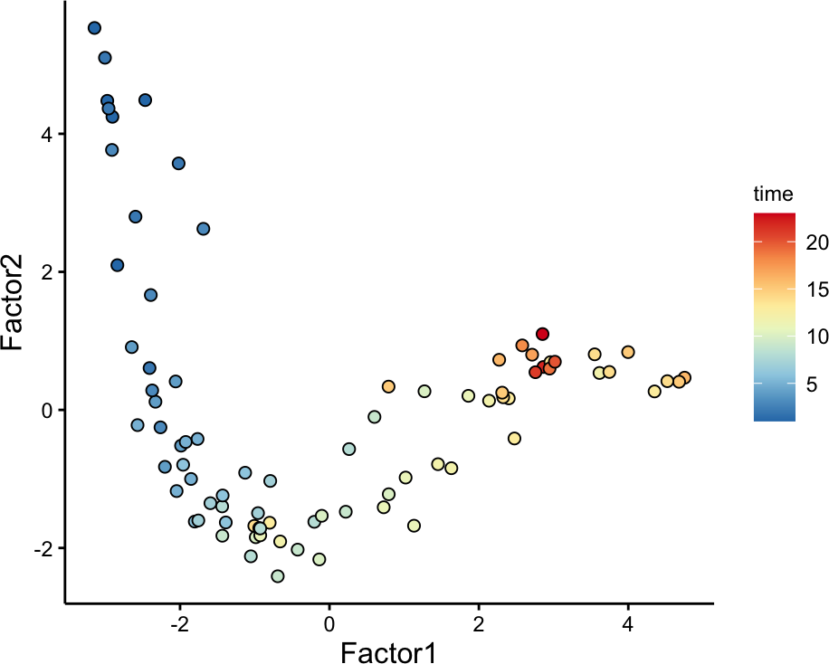

```r
plot_factors(MOFAobject, 1:2, color_by = "time")
```

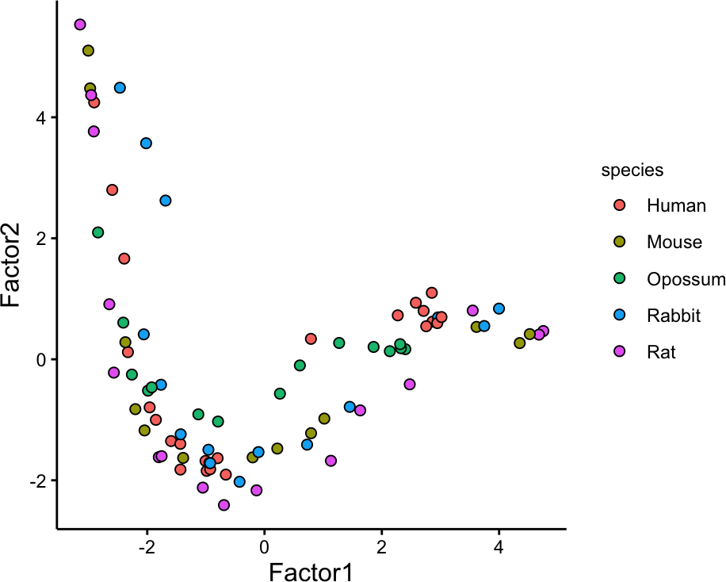

```r
plot_factors(MOFAobject, 1:2, color_by = "species")
```

# 4 Alignment

Next, we further look into the alignment that was learnt by the model by plotting the mapping of mouse developmental stages to the stages of other species.

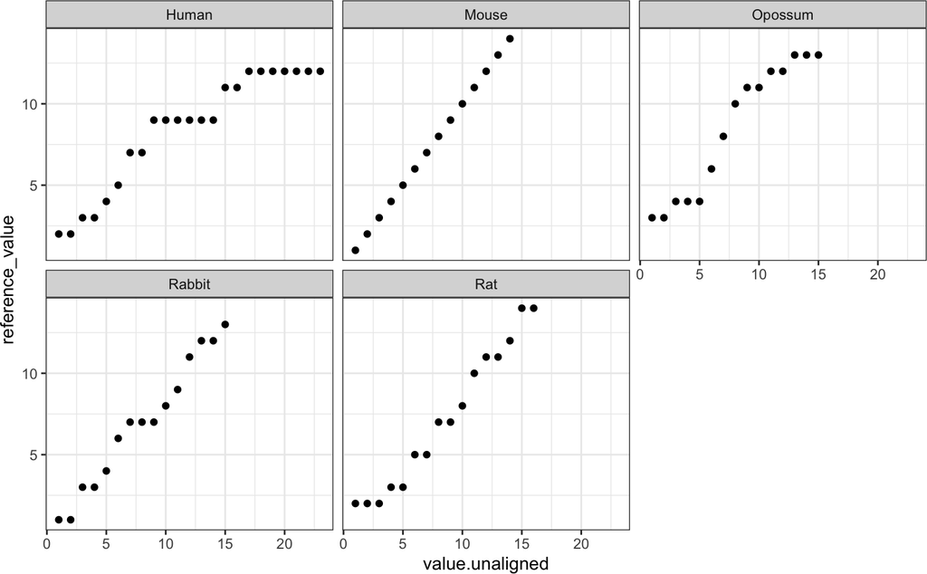

```r
plot_alignment(MOFAobject)
```

# 5 Smoothness and sharedness of factors: Investigating the learnt hyper parameters

In addition to the factor values and the alignment the model also inferred an underlying Gaussian process that generated these values. By looking into it we can extract information on the smoothness of each factor, i.e. how smoothly it varies along developmental time, as well as the sharedness of each factor, i.e. how much the species (groups) show the same underlying developmental pattern and how the shape of their developmental trajectory related to a given developmental module (Factor) clusters between species.

## 5.1 Smoothness score

The scale parameters of the Gaussian process capture the smoothness of the model. A scale of 1 indicates high smoothness, a scale of 0 variation independent of time. Here all factors show a very high degree of smoothness.

```r
get_scales(MOFAobject)
```

```
##   Factor1   Factor2   Factor3   Factor4   Factor5
## 0.9182398 0.8032560 0.8039605 0.8853431 0.9534674
```

For visualization we visualize the scale of the Gaussian process as a smoothness score in a barplot for each factor. No color indicates no smoothness, a fully colored bar a very smooth factor.

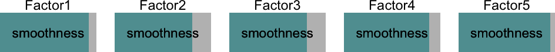

```r
plot_smoothness(MOFAobject)
```

## 5.2 Sharedness

The group kernel of the Gaussian process can give us insights into the extent to which a temporal pattern is shared across species for the developmental module captured by each process. Here, we see a strong clustering of the first processes, indicating that these are conserved in evolution of the species, while the last two processes show distinct clusters.

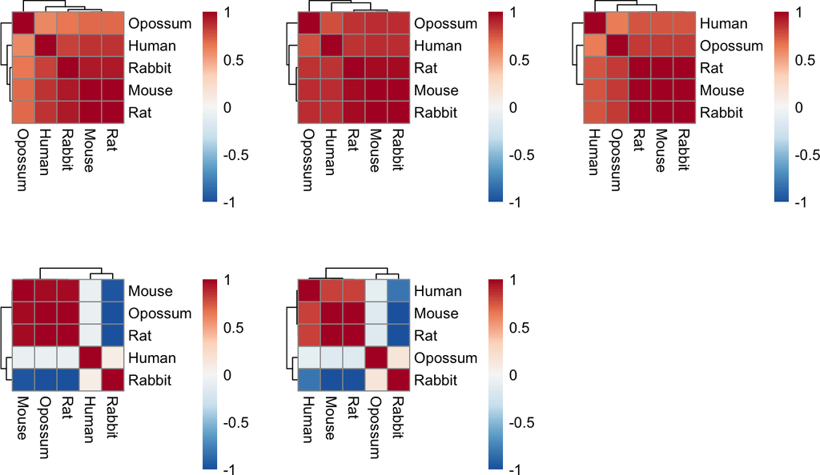

```r
# We can use the following, below we make some more custom plot
plot_group_kernel(MOFAobject, factors = "all",
                  cellheight =  15, cellwidth = 15,
                  treeheight_col = 3, treeheight_row = 3)
```

For visualization we calculate an overall sharedness score per factor between 0 and 1. No color indicates no sharedness, a fully colored bar a fully shared factor.

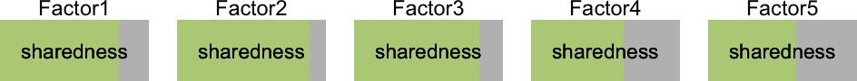

```r
plot_sharedness(MOFAobject)
```

# 6 Factor weights: Gene set enrichment analysis and inspection of genes with top weights per factor

**Question 4: We now want to see what are the top features in the “Brain” view that contribute to Factor 1, i.e. the features with highest weights on Factor 1. How to do it?**

## 6.1 Let’s take a look at these genes over the developmental time.

Factor 1 captures genes with a smooth up/downregulation of expression across all species.

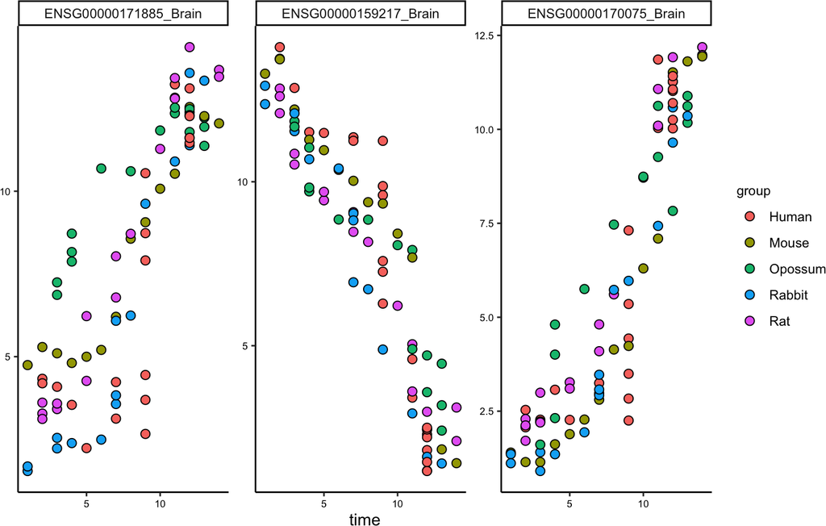

```r
plot_data_vs_cov(MOFAobject, factor = 1,
                 view = "Brain",
                 features = 3)
```

Factor 3 captures a sharp expression change in testis.

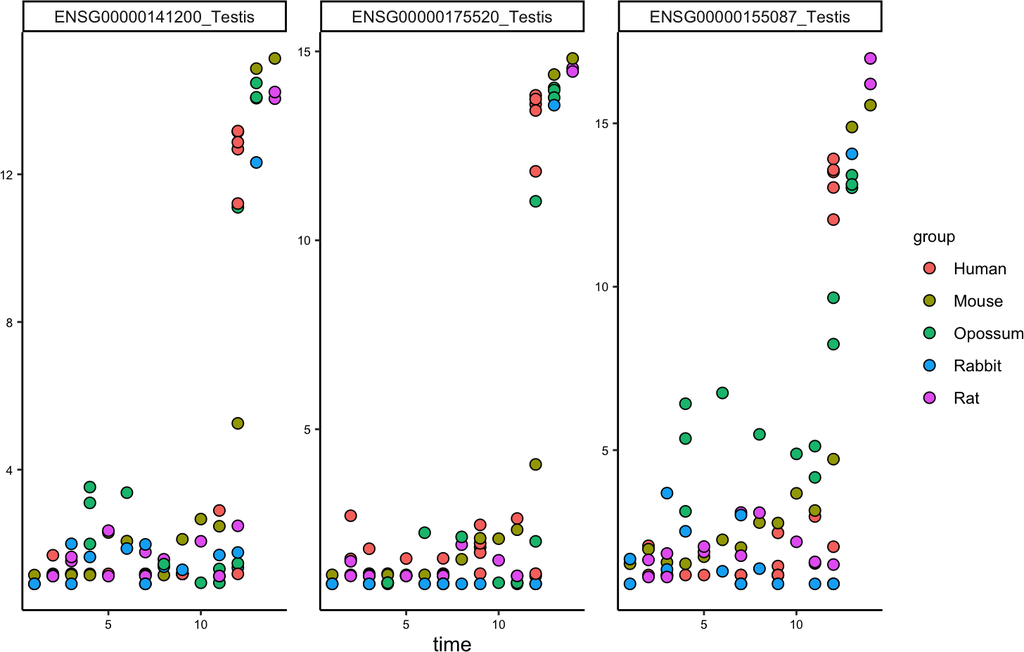

```r
plot_data_vs_cov(MOFAobject, factor = 3,
                 view ="Testis",
                 features = 3)
```

For factor 4, we see that human expression trajectories stand out.

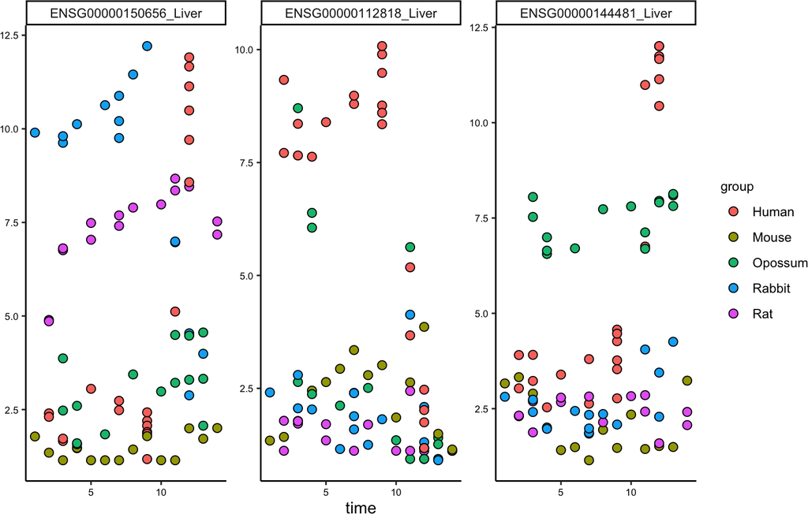

```r
plot_data_vs_cov(MOFAobject, factor = 4,
                 view ="Liver",
                 features = 3)
```

**Question 5: We now want to use gene set enrichment analysis to understand the biology behind inferred factors. Based on what you have learnt from the previous tutorial, can you perform gene set enrichment analysis using the `run_enrichment()` function implemented in the MOFA2 package to investigate the pathways associated with Factor 1 in the view of “Brain”?**

# 7 Solutions

## 7.1 Question 1

Because the `evodevo` data frame is a “tidy table”, we can easily use ggplot2 to visualize the data distribution for each view.

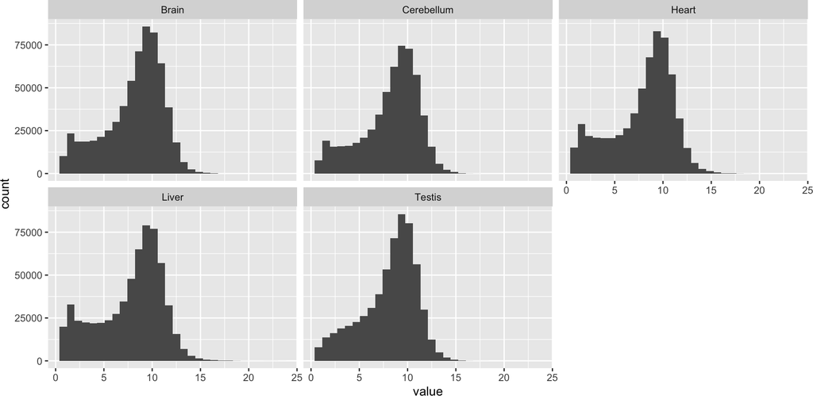

```r
ggplot(evodevo, aes(x=value)) +
    geom_histogram() +
    facet_wrap(~view)
```

It is important to get an overview of the data distribution before running MOFA because we need to use a correct likelihood model for each view: ‘gaussian’ for continuous data (Default for all views), ‘bernoulli’ for binary data and ‘poisson’ for count data. According to the histograms, the data in all views are continuous and approximately normally distributed, so we can use the default “gaussian” likelihood model for all the views.

## 7.2 Question 2

In this tutorial, the `evodevo` data frame is a “tidy table”, i.e. long table format. The “View” and “Group” information are encoded in the columns named “view” and “group”, respectively. In the previous CLL tutorial, the input data for `create_mofa()` function is a list of matrices, with each view as an element in the list. If you have group structure, it is easier to create input MOFA object using the “tidy table” format. The `create_mofa()` can take several types of data as input. Please look at the help page for the `create_mofa()` function (typing `?create_mofa` in the Console) for more information.

## 7.3 Question 3

Usually the first analysis step for a trained MOFA model is to obtain an overview of the factors and take a look at the variance that a factor explains in each view (“organs” in this example) and group (“species” in this example).

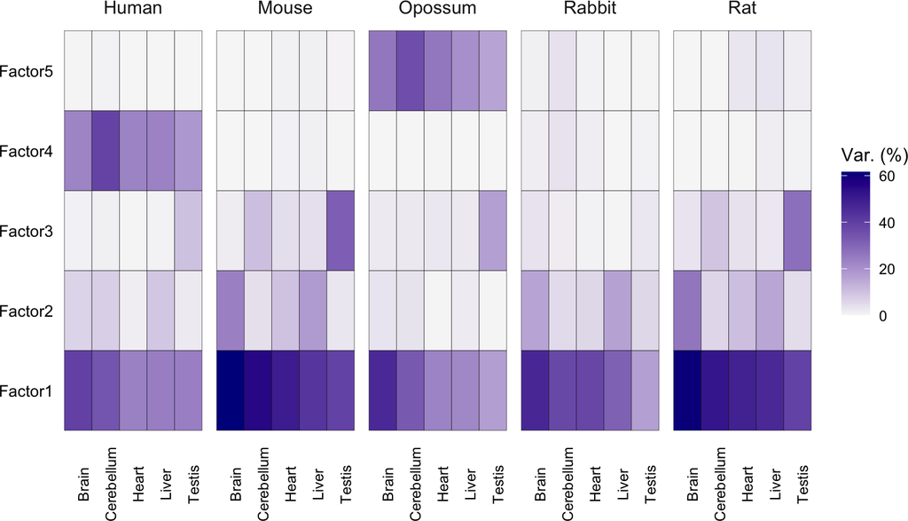

```r
p <- plot_variance_explained(MOFAobject, plot_total = T)
p[[1]] + theme(axis.text.x = element_text(angle = 90))
```

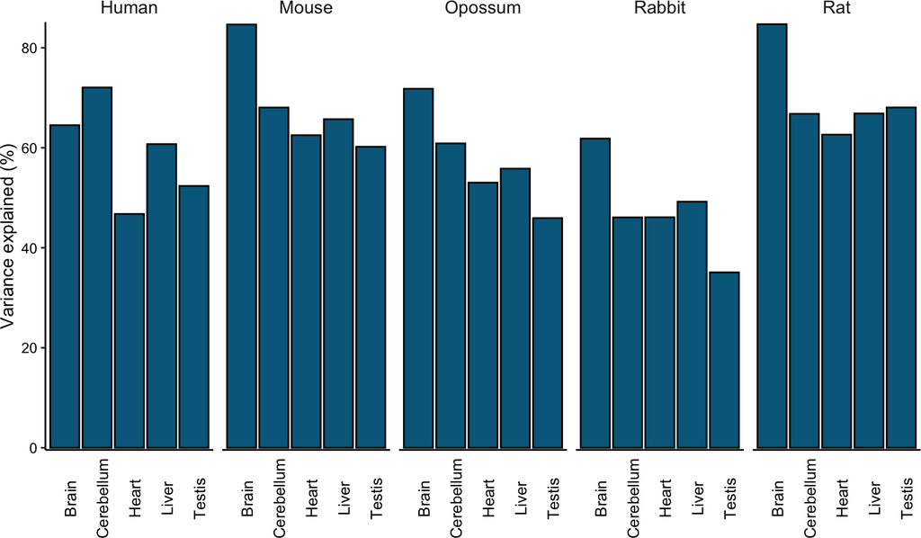

```r
p[[2]] + theme(axis.text.x = element_text(angle = 90))
```

## Question 4:

### 7.3.1 Inspection of top genes per factor

To obtain insights into the molecular signatures associated with each factor in each organ, we can inspect the genes that have high weights on the factors as well as carry out an enrichment analysis to obtain gene sets that are associated to the process.

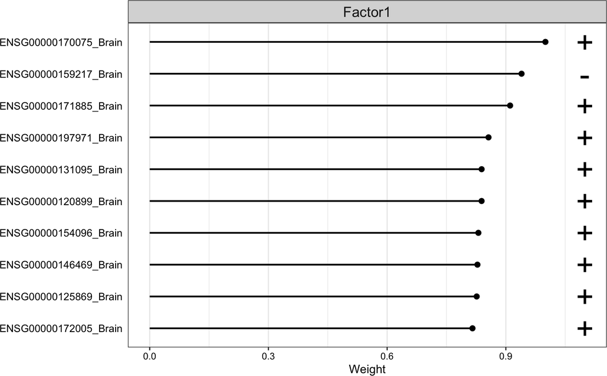

```r
plot_top_weights(MOFAobject, view = "Brain", factors = 1)
```

## 7.4 Question 5:

### 7.4.1 Gene set enrichment analysis

To aggregate information on factors from individual genes to gene sets we can use enrichment analysis on each factor and for each organ by running `run_enrichment`. We illustrate this here for Brain, for other organs you can do this in an analogous manner.

See our MOFA tutorial on enrichment analysis for details.

```r
data("reactomeGS", package = "MOFAdata")
reactomeGS <- reactomeGS[!is.na(rownames(reactomeGS)),]

# we rename the feature to match the gene names in the gene sets
# by removing the organ parts
MOFAobject_renamed <- MOFAobject
features_names(MOFAobject_renamed) <- lapply(features_names(MOFAobject_renamed),
                                             function(l) gsub("_.*","", l))

res <- run_enrichment(MOFAobject_renamed,
    view = "Brain", factors = "all",
    feature.sets = reactomeGS,
    statistical.test = "parametric")
```

```
## Intersecting features names in the model and the gene set annotation results in a total of 7682 features.
```

```
##
## Running feature set Enrichment Analysis with the following options...
## View: Brain
## Number of feature sets: 890
## Set statistic: mean.diff
## Statistical test: parametric
```

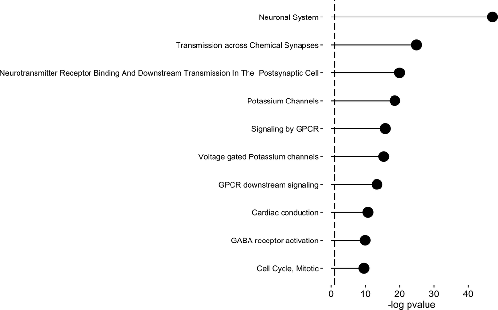

```r
# show top 10 pathways for Factor 1
plot_enrichment(res, factor = 1, max.pathways = 10)
```